# R Notebook

# Make figures for ESA 2024 presentation

[output not shown]

## Question 1: How do heat waves affect nestling birds across land cover types?

### Hypothesis 1: forest is coolest, then orchard, grassland, row crop

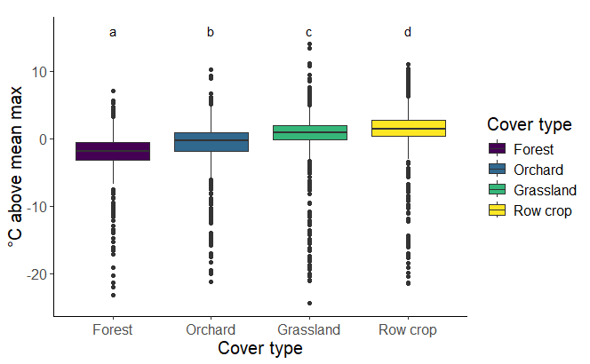

```
  Tukey multiple comparisons of means
    95% family-wise confidence level

Fit: aov(formula = resid ~ habitat, data = filter(wmean, logger_position == \O\))

$habitat
                        diff       lwr       upr p adj
Orchard-Forest     1.2619559 1.0994510 1.4244609     0
Grassland-Forest   2.6088735 2.4521625 2.7655844     0
Row crop-Forest    3.3670748 3.2113005 3.5228490     0
Grassland-Orchard  1.3469176 1.1925161 1.5013190     0
Row crop-Orchard   2.1051188 1.9516682 2.2585694     0
Row crop-Grassland 0.7582013 0.6109004 0.9055022     0
```

### Hypothesis 2: Nestling growth declines with temperature

```
Call:
lm(formula = gweight ~ meanmaxtempI + I(meanmaxtempI^2), data = g %>%
    filter(Species == \WEBL\))

Residuals:
    Min      1Q  Median      3Q     Max
-2.1063 -0.5998  0.1272  0.6256  1.6880

Coefficients:
                   Estimate Std. Error t value Pr(>|t|)
(Intercept)       -1.441617   1.314467  -1.097   0.2734
meanmaxtempI       0.202720   0.084296   2.405   0.0166 *
I(meanmaxtempI^2) -0.003396   0.001336  -2.542   0.0114 *
---
Signif. codes:  0 ‘***’ 0.001 ‘**’ 0.01 ‘*’ 0.05 ‘.’ 0.1 ‘ ’ 1

Residual standard error: 0.7917 on 435 degrees of freedom
  (26 observations deleted due to missingness)
Multiple R-squared:  0.01842,   Adjusted R-squared:  0.01391
F-statistic: 4.082 on 2 and 435 DF,  p-value: 0.01752
```

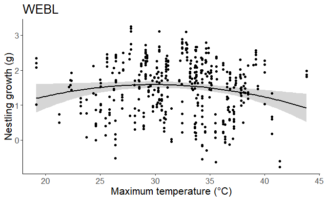

```
Call:
lm(formula = gweight ~ meanmaxtempI + I(meanmaxtempI^2), data = g %>%
    filter(Species == \TRES\))

Residuals:
    Min      1Q  Median      3Q     Max
-1.7224 -0.3697  0.0749  0.4266  1.3223

Coefficients:
                    Estimate Std. Error t value Pr(>|t|)
(Intercept)        3.5490342  0.9169813   3.870  0.00013 ***
meanmaxtempI      -0.1024460  0.0496663  -2.063  0.03988 *
I(meanmaxtempI^2)  0.0010342  0.0006699   1.544  0.12354
---
Signif. codes:  0 ‘***’ 0.001 ‘**’ 0.01 ‘*’ 0.05 ‘.’ 0.1 ‘ ’ 1

Residual standard error: 0.5917 on 350 degrees of freedom
  (28 observations deleted due to missingness)
Multiple R-squared:  0.04451,   Adjusted R-squared:  0.03905
F-statistic: 8.151 on 2 and 350 DF,  p-value: 0.0003467
```

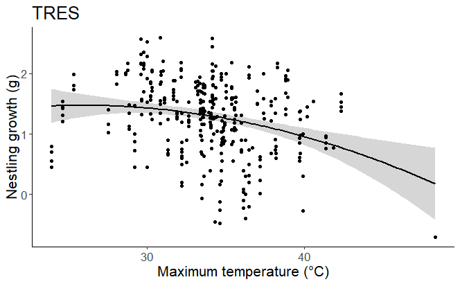

## Question 2: How does the effect of heat on growth vary across land cover types?

### Hypothesis 1: Forest and orchard have relatively more canopy cover than grassland and row crop

Should use canopy cover instead of wmean, or filter wmean down to unique combos of year & cc & box

```
  Tukey multiple comparisons of means
    95% family-wise confidence level

Fit: aov(formula = canopy_cover ~ habitat, data = unique_canopy_measures, conf.level = 0.95)

$habitat
                        diff       lwr         upr     p adj
Orchard-Forest     -13.18576 -26.10802  -0.2635098 0.0435601
Grassland-Forest   -59.49844 -71.37742 -47.6194602 0.0000000
Row crop-Forest    -63.02684 -75.49977 -50.5539114 0.0000000
Grassland-Orchard  -46.31268 -58.02312 -34.6022400 0.0000000
Row crop-Orchard   -49.84108 -62.15360 -37.5285581 0.0000000
Row crop-Grassland  -3.52840 -14.74106   7.6842609 0.8470921
```

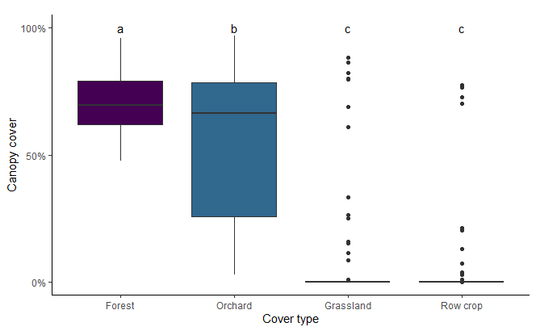

### Hypothesis 2: Internal nest box temp decreases with increasing canopy cover

```
Warning: Removed 1303 rows containing non-finite outside the scale
range (`stat_smooth()`).
Warning: Removed 1303 rows containing missing values or values
outside the scale range (`geom_point()`).

Call:
lm(formula = resid ~ canopy_cover, data = wmean)

Residuals:
    Min      1Q  Median      3Q     Max
-25.337  -1.317  -0.042   1.340  39.615

Coefficients:
               Estimate Std. Error t value Pr(>|t|)
(Intercept)   0.9922093  0.0229550   43.22   <2e-16 ***
canopy_cover -0.0271343  0.0004651  -58.34   <2e-16 ***
---
Signif. codes:
0 ‘***’ 0.001 ‘**’ 0.01 ‘*’ 0.05 ‘.’ 0.1 ‘ ’ 1

Residual standard error: 2.924 on 30194 degrees of freedom
  (1303 observations deleted due to missingness)
Multiple R-squared:  0.1013,    Adjusted R-squared:  0.1013
F-statistic:  3403 on 1 and 30194 DF,  p-value: < 2.2e-16

Warning: Removed 1303 rows containing non-finite outside the scale
range (`stat_smooth()`).
Warning: Removed 1303 rows containing missing values or values
outside the scale range (`geom_point()`).
```

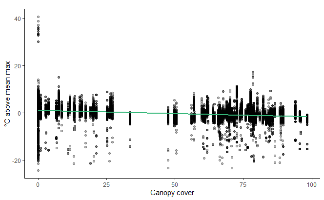

### Hypothesis 3: Agriculture makes nestlings more vulnerable to the negative effects of heat. Prediction: After accounting for the direct effects of heat, heat will still cause growth to decline more in agricultural land uses compared to natural land uses (i.e. there will still be an interactive effect of heat and land cover)

For explanation of why this model is best, check code/danny_meeting_20240213.html

## WEBL

```
boundary (singular) fit: see help('isSingular')
```

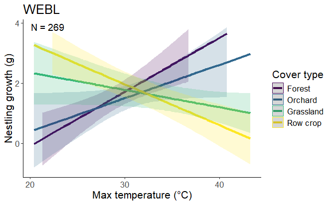

[figure not shown]

[figure not shown]

## TRES

```
boundary (singular) fit: see help('isSingular')
```

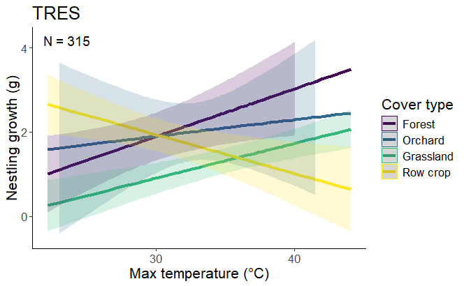

[figure not shown]

[figure not shown]

[figure not shown]

## Question 3: Why is nestling growth disproportionately low under extreme heat in row crop?

### Hypothesis 1: Canopy cover availability reduces costs of behavioral thermoregulation

## WEBL

```
fixed-effect model matrix is rank deficient so dropping 2 columns / coefficients
boundary (singular) fit: see help('isSingular')
```

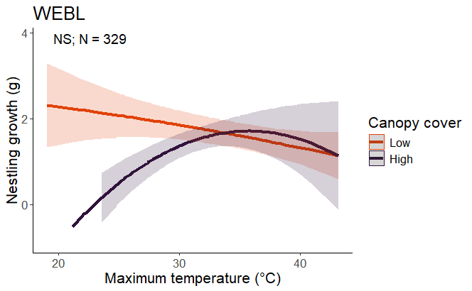

[figure not shown]

## TRES

```
fixed-effect model matrix is rank deficient so dropping 2 columns / coefficients
boundary (singular) fit: see help('isSingular')
```

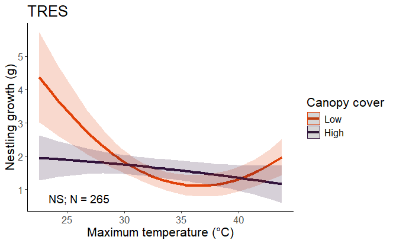

[figure not shown]

### Hypothesis 2: Irrigation supplements dietary water and facilitates evaporative cooling

## WEBL

```
boundary (singular) fit: see help('isSingular')
```

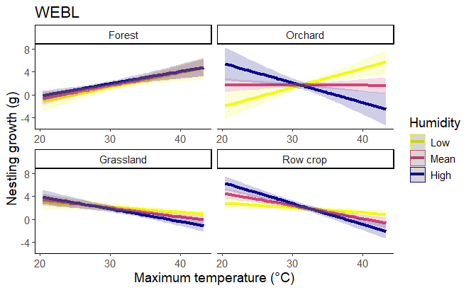

## TRES

```
boundary (singular) fit: see help('isSingular')
```

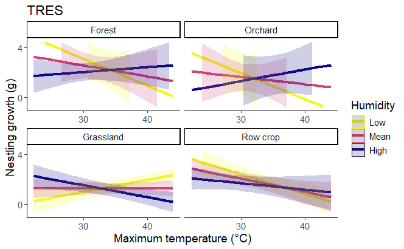

### Hypothesis 3: Forest has 0/2 stressors, Orchard has ag stressors, grassland has heat stressor, row crop has ag and heat stressors. So if this is the cause of interactive effect, and the stressors are chronic, baseline cort should be lowest in row crop. There is a lot of evidence that increased cort is adaptive, so growth should increase with increasing baseline cort.

## WEBL

```r
s1bytemphabitat_WEBL_poly <- lmerTest::lmer(log(cort_s1) ~ poly(meanmaxtempI_scaled,2) * habitat + poly(meanmintempI_scaled,2) * habitat + habitat * meanh_scaled + brood_size + age_scaled + juliandate_scaled + (1|year) + (1|site/attempt_id),
                                       data = (filter(g,Species == "WEBL",
                                                     # !is.nan(cort_s1),
                                                     !is.na(meanmaxtempI),
                                                     !is.na(cort_s1)) %>%
                                    mutate(across(c(cort_s1,
                                                    meanmaxtempI,
                                                    meanmintempI,
                                                    meanh,
                                                    cort_s1_mother,
                                                    age,
                                                    juliandate),
                                                  ~ scale(.x)[,1],
                                                  .names = "{.col}_scaled"),
                                           meanmaxtempI_scaled_sq =
                                             meanmaxtempI_scaled * meanmaxtempI_scaled)))

s1bytemphabitat_WEBL_add <- lmerTest::lmer(log(cort_s1) ~ poly(meanmaxtempI_scaled,2) + poly(meanmintempI_scaled,2) * habitat + habitat * meanh_scaled + brood_size + age_scaled + juliandate_scaled + (1|year) + (1|site/attempt_id),
                                       data = (filter(g,Species == "WEBL",
                                                     # !is.nan(cort_s1),
                                                     !is.na(meanmaxtempI),
                                                     !is.na(cort_s1)) %>%
                                    mutate(across(c(cort_s1,
                                                    meanmaxtempI,
                                                    meanmintempI,
                                                    meanh,
                                                    cort_s1_mother,
                                                    age,
                                                    juliandate),
                                                  ~ scale(.x)[,1],
                                                  .names = "{.col}_scaled"),
                                           meanmaxtempI_scaled_sq =
                                             meanmaxtempI_scaled * meanmaxtempI_scaled)))
```

```
boundary (singular) fit: see help('isSingular')
```

```r
s1bytemphabitat_WEBL_notemp <- lmerTest::lmer(log(cort_s1) ~ poly(meanmintempI_scaled,2) * habitat + habitat * meanh_scaled + brood_size + age_scaled + juliandate_scaled + (1|year) + (1|site/attempt_id),
                                       data = (filter(g,Species == "WEBL",
                                                     # !is.nan(cort_s1),
                                                     !is.na(meanmaxtempI),
                                                     !is.na(cort_s1)) %>%
                                    mutate(across(c(cort_s1,
                                                    meanmaxtempI,
                                                    meanmintempI,
                                                    meanh,
                                                    cort_s1_mother,
                                                    age,
                                                    juliandate),
                                                  ~ scale(.x)[,1],
                                                  .names = "{.col}_scaled"),
                                           meanmaxtempI_scaled_sq =
                                             meanmaxtempI_scaled * meanmaxtempI_scaled)))
```

```
boundary (singular) fit: see help('isSingular')
```

```r
s1bytemphabitat_WEBL_tempnohab <- lmerTest::lmer(log(cort_s1) ~ poly(meanmaxtempI_scaled,2) + poly(meanmintempI_scaled,2) + meanh_scaled + brood_size + age_scaled + juliandate_scaled + (1|year) + (1|site/attempt_id),
                                       data = (filter(g,Species == "WEBL",
                                                     # !is.nan(cort_s1),
                                                     !is.na(meanmaxtempI),
                                                     !is.na(cort_s1)) %>%
                                    mutate(across(c(cort_s1,
                                                    meanmaxtempI,
                                                    meanmintempI,
                                                    meanh,
                                                    cort_s1_mother,
                                                    age,
                                                    juliandate),
                                                  ~ scale(.x)[,1],
                                                  .names = "{.col}_scaled"),
                                           meanmaxtempI_scaled_sq =
                                             meanmaxtempI_scaled * meanmaxtempI_scaled)))
```

```
boundary (singular) fit: see help('isSingular')
```

```r
anova(s1bytemphabitat_WEBL_tempnohab,s1bytemphabitat_WEBL_poly,s1bytemphabitat_WEBL_add,s1bytemphabitat_WEBL_notemp)
```

```
refitting model(s) with ML (instead of REML)
```

```
Data: (filter(g, Species == "WEBL", !is.na(meanmaxtempI), !is.na(cort_s1)) %>%  ...
Models:
s1bytemphabitat_WEBL_tempnohab: log(cort_s1) ~ poly(meanmaxtempI_scaled, 2) + poly(meanmintempI_scaled, 2) + meanh_scaled + brood_size + age_scaled + juliandate_scaled + (1 | year) + (1 | site/attempt_id)
s1bytemphabitat_WEBL_notemp: log(cort_s1) ~ poly(meanmintempI_scaled, 2) * habitat + habitat * meanh_scaled + brood_size + age_scaled + juliandate_scaled + (1 | year) + (1 | site/attempt_id)
s1bytemphabitat_WEBL_add: log(cort_s1) ~ poly(meanmaxtempI_scaled, 2) + poly(meanmintempI_scaled, 2) * habitat + habitat * meanh_scaled + brood_size + age_scaled + juliandate_scaled + (1 | year) + (1 | site/attempt_id)
s1bytemphabitat_WEBL_poly: log(cort_s1) ~ poly(meanmaxtempI_scaled, 2) * habitat + poly(meanmintempI_scaled, 2) * habitat + habitat * meanh_scaled + brood_size + age_scaled + juliandate_scaled + (1 | year) + (1 | site/attempt_id)
                               npar    AIC    BIC  logLik deviance   Chisq Df Pr(>Chisq)
s1bytemphabitat_WEBL_tempnohab   13 199.03 234.94 -86.518   173.03
s1bytemphabitat_WEBL_notemp      23 202.33 265.86 -78.167   156.33 16.7015 10    0.08123 .
s1bytemphabitat_WEBL_add         25 205.53 274.59 -77.766   155.53  0.8018  2    0.66971
s1bytemphabitat_WEBL_poly        31 210.52 296.15 -74.261   148.52  7.0091  6    0.32001
---
Signif. codes:  0 ‘***’ 0.001 ‘**’ 0.01 ‘*’ 0.05 ‘.’ 0.1 ‘ ’ 1
```

```
Model has log-transformed response. Back-transforming predictions to original response scale. Standard errors are still on the
  log-scale.
```

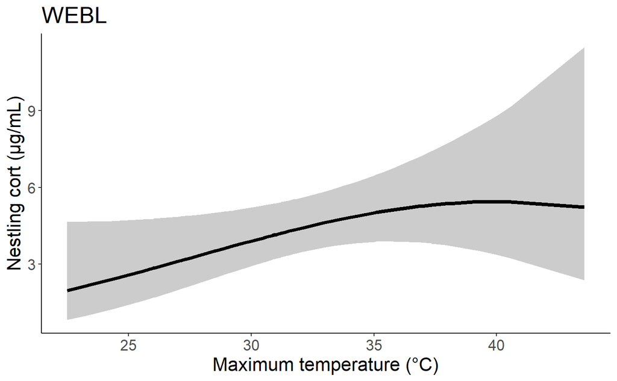